# homework_6

Emma-Marie Vitskov Jørgensen

2022-11-03, updated 07 November, 2022

In this assignment I will be scraping some data from the danish church ministry. I chose to inspect a data set containing data about the percentage of members of the Danish National Church in different danish cities through several years.

I start out by activating some packages which will help me scrape, wrangle and transform the data.

```r
library(rvest) #for web-scraping
library(dplyr) #for data-wrangling
library(tidyr) #for data transformation
library(stringr) #for string manipulation
library(janitor) #for clean headers
library(tidyverse)
```

Now I scrape the data from the church ministry webside:

```r
url <- "https://www.km.dk/folkekirken/kirkestatistik/folkekirkens-medlemstal"
# scrape the website
url_html <- read_html(url)
```

I extract the whole HTML table into a list.

```r
whole_table <- url_html %>%
 html_nodes("table") %>% # just graps the table from the website
 html_table()
head(whole_table)
```

```
## [[1]]
## # A tibble: 14 × 4
##    X1                       X2           X3                         X4
##    <chr>                    <chr>        <chr>                      <chr>
##  1 "Pr. 1. januar 2020"     "Indbyggere" "Medlemmer af folkekirken" "Medlems- p…
##  2 ""                       ""           ""                         ""
##  3 "Hele landet"            "5.822.763"  "4.327.018"                "74,3"
##  4 ""                       ""           ""                         ""
##  5 "Københavns Stift"       "833.711"    "470.401"                  "56,4"
##  6 "Helsingør Stift"        "1.012.312"  "679.276"                  "67,1"
##  7 "Roskilde Stift"         "735.532"    "574.372"                  "78,1"
##  8 "Lolland-Falsters Stift" "101.827"    "82.119"                   "80,6"
##  9 "Fyens Stift"            "498.506"    "393.961"                  "79,0"
## 10 "Aalborg Stift"          "529.469"    "437.982"                  "82,7"
## 11 "Viborg Stift"           "417.470"    "350.381"                  "83,9"
```

[output cut: 19 more lines]

```r
str(whole_table) #whole_table turns out to be a list
```

```
## List of 2
##  $ : tibble [14 × 4] (S3: tbl_df/tbl/data.frame)
##   ..$ X1: chr [1:14] "Pr. 1. januar 2020" "" "Hele landet" "" ...
##   ..$ X2: chr [1:14] "Indbyggere" "" "5.822.763" "" ...
##   ..$ X3: chr [1:14] "Medlemmer af folkekirken" "" "4.327.018" "" ...
##   ..$ X4: chr [1:14] "Medlems- procent" "" "74,3" "" ...
##  $ : tibble [32 × 12] (S3: tbl_df/tbl/data.frame)
##   ..$ X1 : chr [1:32] "Medlems- \t\t\tprocent" "2020" "2019" "2018" ...
##   ..$ X2 : chr [1:32] "Hele landet" "74,3" "74,7" "75,3" ...
##   ..$ X3 : chr [1:32] "Køben- \t\t\thavn" "56,4" "56,9" "57,5" ...
##   ..$ X4 : chr [1:32] "Helsin- \t\t\tgør" "67,1" "67,6" "68,3" ...
##   ..$ X5 : chr [1:32] "Roskil- \t\t\tde" "78,1" "78,5" "79,0" ...
##   ..$ X6 : chr [1:32] "Lolland- \t\t\tFalster" "80,6" "80,9" "81,2" ...
##   ..$ X7 : chr [1:32] "Fyen" "79,0" "79,2" "79,8" ...
##   ..$ X8 : chr [1:32] "Aal- \t\t\tborg" "82,7" "83,0" "83,3" ...
##   ..$ X9 : chr [1:32] "Vi- \t\t\tborg" "83,9" "84,2" "84,6" ...
##   ..$ X10: chr [1:32] "Århus" "77,0" "77,4" "77,8" ...
##   ..$ X11: chr [1:32] "Ribe" "83,1" "83,5" "84,0" ...
##   ..$ X12: chr [1:32] "Hader- \t\t\tslev" "79,6" "80,1" "80,7" ...
```

I will turn the data into a table instead of a list.

```r
new_table <- do.call(cbind,unlist(whole_table, recursive = FALSE)) #unlists the downloaded html table and combine the individual elements as columns.
head(new_table)
```

```
##      X1                   X2           X3
## [1,] "Pr. 1. januar 2020" "Indbyggere" "Medlemmer af folkekirken"
## [2,] ""                   ""           ""
## [3,] "Hele landet"        "5.822.763"  "4.327.018"
## [4,] ""                   ""           ""
## [5,] "Københavns Stift"   "833.711"    "470.401"
## [6,] "Helsingør Stift"    "1.012.312"  "679.276"
##      X4                 X1                       X2
## [1,] "Medlems- procent" "Medlems- \t\t\tprocent" "Hele landet"
## [2,] ""                 "2020"                   "74,3"
## [3,] "74,3"             "2019"                   "74,7"
## [4,] ""                 "2018"                   "75,3"
## [5,] "56,4"             "2017"                   "75,9"
## [6,] "67,1"             "2016"                   "76,9"
##      X3                  X4                  X5
```

[output cut: 20 more lines]

```r
class(new_table) # the data is a matrix and array.
```

```
## [1] "matrix" "array"
```

```r
head(new_table)
```

```
##      X1                   X2           X3
## [1,] "Pr. 1. januar 2020" "Indbyggere" "Medlemmer af folkekirken"
## [2,] ""                   ""           ""
## [3,] "Hele landet"        "5.822.763"  "4.327.018"
## [4,] ""                   ""           ""
## [5,] "Københavns Stift"   "833.711"    "470.401"
## [6,] "Helsingør Stift"    "1.012.312"  "679.276"
##      X4                 X1                       X2
## [1,] "Medlems- procent" "Medlems- \t\t\tprocent" "Hele landet"
## [2,] ""                 "2020"                   "74,3"
## [3,] "74,3"             "2019"                   "74,7"
## [4,] ""                 "2018"                   "75,3"
## [5,] "56,4"             "2017"                   "75,9"
## [6,] "67,1"             "2016"                   "76,9"
##      X3                  X4                  X5
```

[output cut: 20 more lines]

## Cleaning the scraped data

The scraped data consists of two tables: one containing the number of members in different church diocese on January 1st 2020, and one containing the percentage of church members in the church divided by year and different danish cities. I am only interested in the second table, but right now the two tables are in the same table. Therefore I will separate the two tables into individual tables.

```r
ncol(new_table) #counting the number of rows in the data set, there is 16.
```

```
## [1] 16
```

```r
table1 <- new_table[ , 1:4] # turning the first 4 columns into a table.
table2 <- new_table[ ,5:12 ] # turning the last 8 columns into a table

head(table1)
```

```
##      X1                   X2           X3
## [1,] "Pr. 1. januar 2020" "Indbyggere" "Medlemmer af folkekirken"
## [2,] ""                   ""           ""
## [3,] "Hele landet"        "5.822.763"  "4.327.018"
## [4,] ""                   ""           ""
## [5,] "Københavns Stift"   "833.711"    "470.401"
## [6,] "Helsingør Stift"    "1.012.312"  "679.276"
##      X4
## [1,] "Medlems- procent"
## [2,] ""
## [3,] "74,3"
## [4,] ""
## [5,] "56,4"
## [6,] "67,1"
```

```r
tail(table1)
```

```
##       X1                   X2           X3
## [27,] "Ribe Stift"         "356.022"    "295.986"
## [28,] "Haderslev Stift"    "478.084"    "380.756"
## [29,] "Pr. 1. januar 2020" "Indbyggere" "Medlemmer af folkekirken"
## [30,] ""                   ""           ""
## [31,] "Hele landet"        "5.822.763"  "4.327.018"
## [32,] ""                   ""           ""
##       X4
## [27,] "83,1"
## [28,] "79,6"
## [29,] "Medlems- procent"
## [30,] ""
## [31,] "74,3"
## [32,] ""
```

```r
head(table2)
```

```
##      X1                       X2            X3
## [1,] "Medlems- \t\t\tprocent" "Hele landet" "Køben- \t\t\thavn"
## [2,] "2020"                   "74,3"        "56,4"
## [3,] "2019"                   "74,7"        "56,9"
## [4,] "2018"                   "75,3"        "57,5"
## [5,] "2017"                   "75,9"        "58,1"
## [6,] "2016"                   "76,9"        "59,3"
##      X4                  X5                 X6                       X7
## [1,] "Helsin- \t\t\tgør" "Roskil- \t\t\tde" "Lolland- \t\t\tFalster" "Fyen"
## [2,] "67,1"              "78,1"             "80,6"                   "79,0"
## [3,] "67,6"              "78,5"             "80,9"                   "79,2"
## [4,] "68,3"              "79,0"             "81,2"                   "79,8"
## [5,] "69,1"              "79,4"             "81,6"                   "80,3"
## [6,] "70,2"              "80,3"             "82,4"                   "81,1"
##      X8
## [1,] "Aal- \t\t\tborg"
## [2,] "82,7"
## [3,] "83,0"
## [4,] "83,3"
## [5,] "83,8"
## [6,] "84,6"
```

```r
tail(table2)
```

```
##       X1     X2     X3     X4     X5     X6     X7     X8
## [27,] "1995" "87,0" "75,8" "81,0" "88,4" "90,3" "89,9" "92,0"
## [28,] "1994" "87,4" "76,6" "81,3" "88,6" "90,5" "90,1" "92,2"
## [29,] "1993" "87,7" "77,4" "81,7" "88,9" "90,9" "90,3" "92,4"
## [30,] "1992" "88,2" "78,3" "82,3" "89,3" "91,3" "90,8" "92,7"
## [31,] "1991" "88,9" "79,5" "83,1" "90,0" "91,7" "91,4" "93,2"
## [32,] "1990" "89,3" "80,3" "83,6" "90,4" "92,1" "91,7" "93,5"
```

The table I will be interested in working with from now on is table2.

I remove row 1 which at the moment contains the citynames that I want as column names.

```r
#Remove row 1
table2 <- table2[-1, ]
head(table2)
```

```
##      X1     X2     X3     X4     X5     X6     X7     X8
## [1,] "2020" "74,3" "56,4" "67,1" "78,1" "80,6" "79,0" "82,7"
## [2,] "2019" "74,7" "56,9" "67,6" "78,5" "80,9" "79,2" "83,0"
## [3,] "2018" "75,3" "57,5" "68,3" "79,0" "81,2" "79,8" "83,3"
## [4,] "2017" "75,9" "58,1" "69,1" "79,4" "81,6" "80,3" "83,8"
## [5,] "2016" "76,9" "59,3" "70,2" "80,3" "82,4" "81,1" "84,6"
## [6,] "2015" "77,8" "60,2" "71,2" "81,2" "83,1" "81,9" "85,4"
```

I will make sure the years and membership percentage is numeric data and I would also like to change my data into a data frame instead of a matrix. I will also change the names of the columns into the names of the cities (which was what was written in the forst column which I removed before) and name the first column “year”.

```r
class(table2[1,1]) # checking random cell with a membership percentage - it is a character
```

```
## [1] "character"
```

```r
church <- gsub(",", ".", table2) #change the "," to an "."
head(church)
```

```
##      X1     X2     X3     X4     X5     X6     X7     X8
## [1,] "2020" "74.3" "56.4" "67.1" "78.1" "80.6" "79.0" "82.7"
## [2,] "2019" "74.7" "56.9" "67.6" "78.5" "80.9" "79.2" "83.0"
## [3,] "2018" "75.3" "57.5" "68.3" "79.0" "81.2" "79.8" "83.3"
## [4,] "2017" "75.9" "58.1" "69.1" "79.4" "81.6" "80.3" "83.8"
## [5,] "2016" "76.9" "59.3" "70.2" "80.3" "82.4" "81.1" "84.6"
## [6,] "2015" "77.8" "60.2" "71.2" "81.2" "83.1" "81.9" "85.4"
```

```r
church <- apply(church, 2, as.numeric) #converting the data into numeric data

church <- as.data.frame(church) #converting the data into a data frame

#Changing the column names
colnames(church)[1] <- "year"
colnames(church)[2] <- "whole_country"
colnames(church)[3] <- "København"
colnames(church)[4] <- "Helsingør"
colnames(church)[5] <- "Roskilde"
colnames(church)[6] <- "Lolland_Falster"
colnames(church)[7] <- "Fyen"
colnames(church)[8] <- "Aalborg"

class(church)# the data is now a data frame
```

```
## [1] "data.frame"
```

```r
head(church)
```

```
##   year whole_country København Helsingør Roskilde Lolland_Falster Fyen Aalborg
## 1 2020          74.3      56.4      67.1     78.1            80.6 79.0    82.7
## 2 2019          74.7      56.9      67.6     78.5            80.9 79.2    83.0
## 3 2018          75.3      57.5      68.3     79.0            81.2 79.8    83.3
## 4 2017          75.9      58.1      69.1     79.4            81.6 80.3    83.8
## 5 2016          76.9      59.3      70.2     80.3            82.4 81.1    84.6
## 6 2015          77.8      60.2      71.2     81.2            83.1 81.9    85.4
```

I export the clean data into a csv file

```r
getwd()
```

```
## [1] "/Users/Emma-Marie/Documents/AU/5. semester/Cultural data science/Homework"
```

```r
readr::write_csv(church,"./churchmembers.csv")
#NB I had to specify the package used (readr) for RStudio to be able to knit it.
```

## Analyzing data

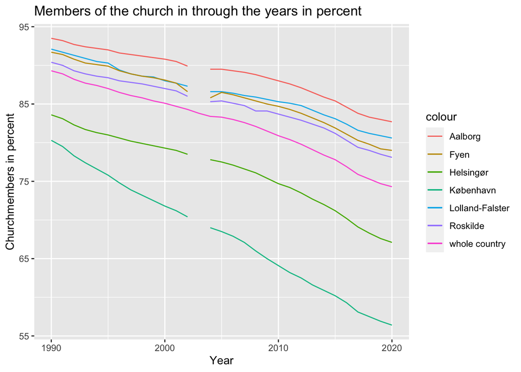

```r
church%>%
  ggplot(aes(x = year)) +
  geom_line(aes(y = whole_country, colour = "whole country")) +
  geom_line(aes(y = København, colour = "København")) +
  geom_line(aes(y = Helsingør, colour = "Helsingør")) +
  geom_line(aes(y = Roskilde, colour = "Roskilde")) +
  geom_line(aes(y = Lolland_Falster, colour = "Lolland-Falster")) +
  geom_line(aes(y = Fyen, colour = "Fyen")) +
  geom_line(aes(y = Aalborg, colour = "Aalborg")) +
  labs(title="Members of the church in through the years in percent",x="Year",y="Churchmembers in percent")
```

```r
  theme_bw()
```

[output not shown]

[output cut: 365 more lines]

[output not shown]

The wholes in many of the lines is due to missing data from year 2003. The percent of church members has generally been declining in all the cities and the whole country from 1990 to 2020. Aalborg has the highest percentage of church members through all the years, and København has the lowest percentage through all the years. Roskilde, Fyen, Lolland-Falster and Aalborg has a higher percentage of church members than the whole country, while only Helsingør and København has a lower percentage og church members that the whole country.